# ミュラーリヤー錯視

遠藤璃星(2412A10)

## 1. 目的 (Introduction)

本研究では、ミュラーリヤー錯視における矢羽の角度が錯覚量に及ぼす影響について検討する。ミュラーリヤー効果とは同じ線分であるにもかかわらず、その両端に付加される矢印の向き（内向・外向）によって、線分の長さが異なるように知覚される視覚的錯視現象である（(Foster, n.d.)）。 本実験の仮説は「角度が鋭い（15条件）の方が、鈍い（75条件）よりも錯覚量が有意に大きくなる。矢羽の長さ（20px条件と50px条件）によって、錯覚量に有意な差が見られる。」とした。

## 2. 方法 (Method)

### 参加者

12名のデータを収集した。

### 装置と材料

オンライン実験プラットフォーム（jsPsych）を使用して作成し、GitHab Pages上に公開した。参加者は各自PCのブラウザから参加した。

### 手続き

実験で参加者は提示された図形に対して主観的価点を測定する調整法を行った。刺激条件は角度2水準×羽の長さ2水準の計4条件であり、ランダムで試行が提示された。

## 3. 結果 (Results)

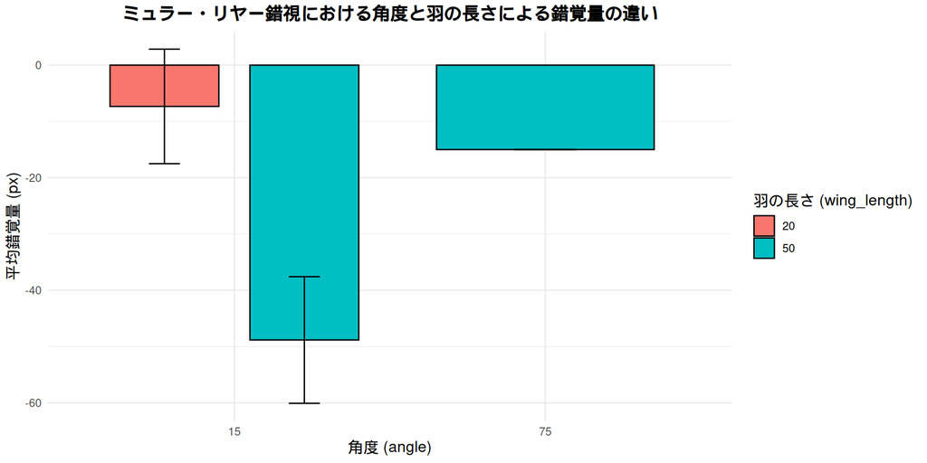

## 5. 引用文献 (References)

Foster, William S. n.d. “The Muller-Lyer Illusion.” In, 90–99. Henry Holt; Company. https://doi.org/10.1037/10966-006.